## Curso de R no IPÊ

### Script do dia 5.1: SIG no R!

*Marcos V. C. Vital e participantes da turma de 2014*

Para mais material, acesse http://marcosvital.wordpress.com/

Este documento é a 1a parte do quinto (e último!) de uma série que nasceu durante as atividades do “Curso de introdução ao uso do software R e suas aplicações estatísticas nas ciências biológicas”, realizado no IPÊ em dezembro de 2014.

Nesta parte do guia nós vamos explorar a capacidade do R em fucionar como um Sistema de Informações Geográficas, lendo e manipulando dados que normalmente são explorados em softwares SIGs.

Como sempre, todo o documento foi criado utilizando o software R, o programa RStudio e a linguagem Markdown. Para saber mais, acesse:

http://www.r-project.org/

http://www.rstudio.com

http://rmarkdown.rstudio.com/

**Antes de começar, carregue os dados e os pacotes necessários:**

```r
library(dismo)
```

```r
library(maptools)
setwd("C:/R/Curso IPÊ")

dados<-read.csv("bradypus.csv")
summary(dados)
```

```
##                 species       dd.long           dd.lat
##  bradypus_variegatus:116   Min.   :-85.93   Min.   :-23.450
##                            1st Qu.:-79.20   1st Qu.: -2.896
##                            Median :-75.08   Median :  4.817
##                            Mean   :-71.79   Mean   :  2.449
##                            3rd Qu.:-65.51   3rd Qu.:  9.150
##                            Max.   :-40.07   Max.   : 13.950
```

```r
dados<-dados[,2:3] #Só precisamos das colunas de longitude e latitude
```

#### Lendo shapefiles e criando mapas

Neste exemplo, nós vamos simplesmente usar um shape que já faz parte do pacote `dismo`, então basta chamá-lo pela função `data`. Mas caso você queira importar dados deste tipo, dê uma olhada na função `shapefile`, ok?

```r
data(wrld_simpl) #Carregar o mapa da memória
```

Para criar um mapa bem simples, é só ir direto no plot:

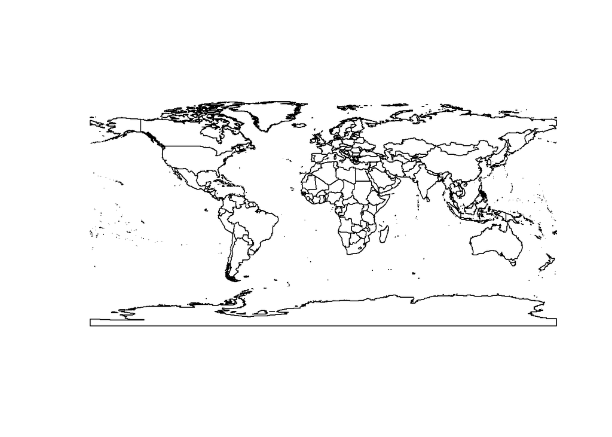

```r
plot(wrld_simpl)
```

Agora vamos alterar um pouquinho o jeitão do mapa, fazer um corte e depois incluir os pontos de distribuição das nossas preguiças:

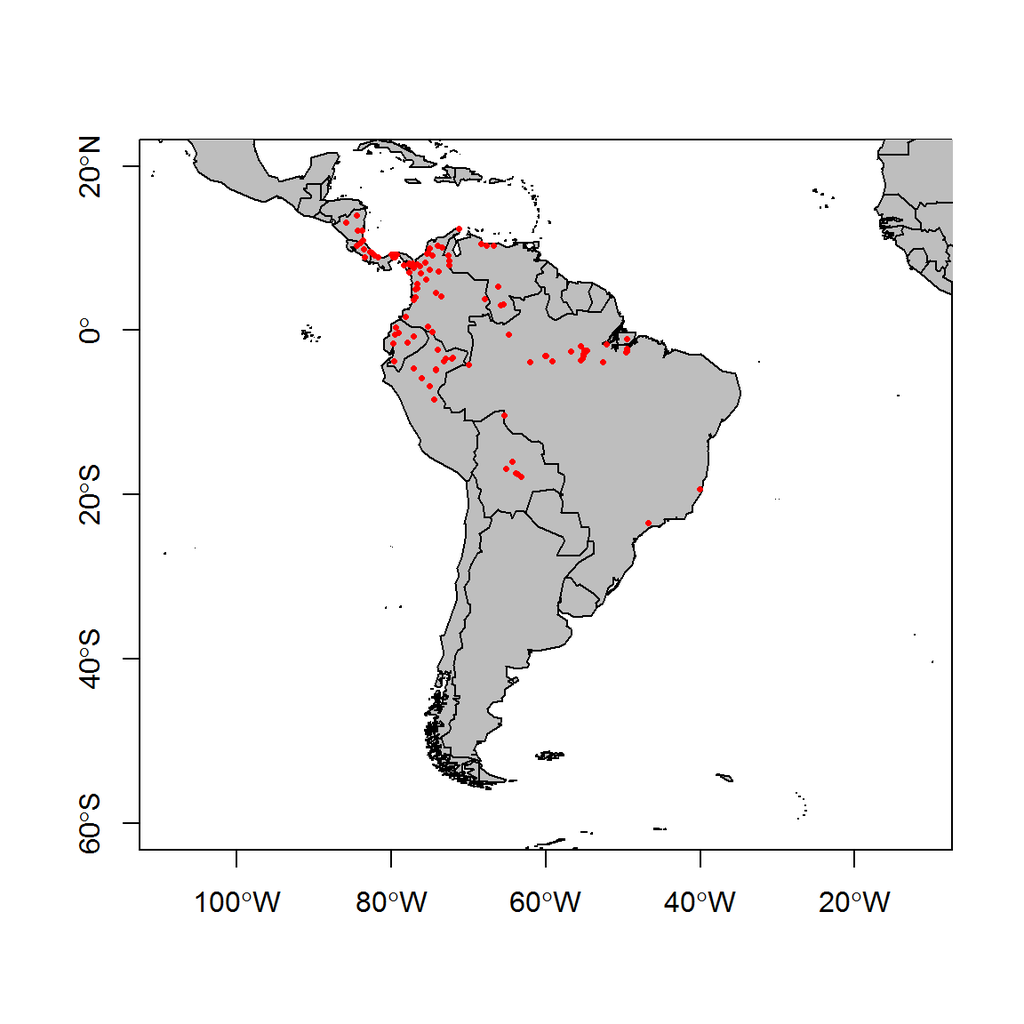

```r
windows(width=6, height=6, rescale="fixed")

plot(wrld_simpl, xlim=c(-90, -30), ylim=c(-60, 20),
axes=T, col="gray")

points(dados, pch=16, col="red", cex=0.5)
```

Perceba uma coisa legal: estamos usando as mesmas funções gráficas de sempre (plot, points, etc)!

**Incluindo informação de outra variável**

Imagine que cada ponto no mapa possua a informação de uma variável quantitativa qualquer. Nós podemos incluí-la no mapa usando pontos cujo tamanho é proporcional ao valor da variável de interesse! Para isso vamos criar uma variável qualquer, ao acaso, apenas para ver como fica, ok?

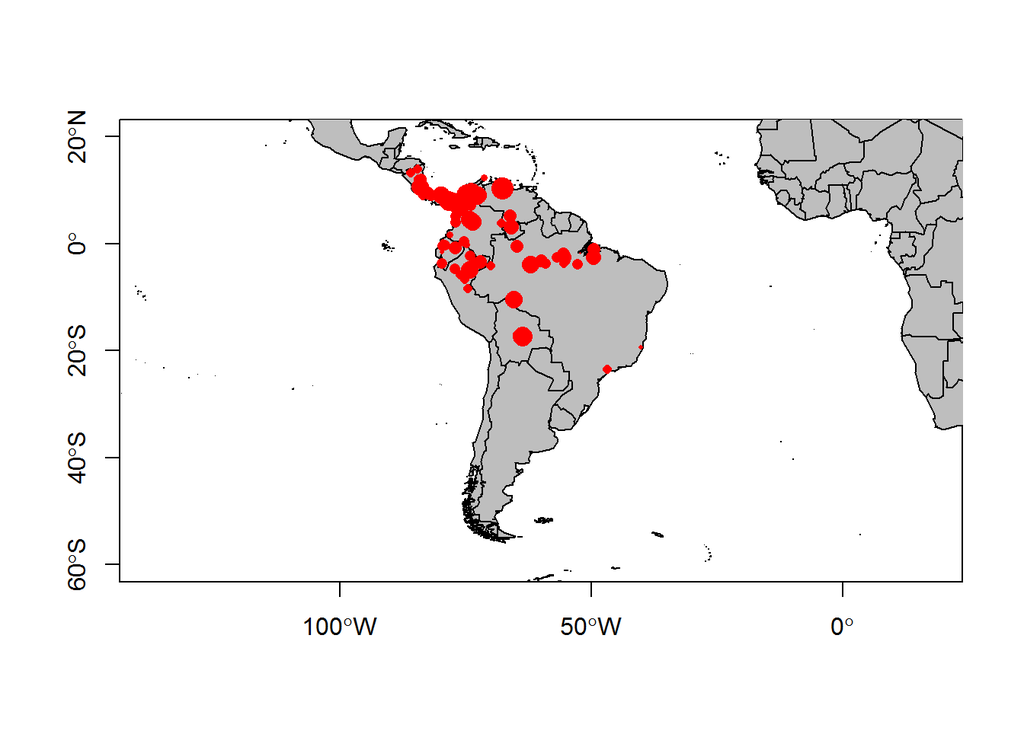

```r
abund<-rpois(nrow(dados), 5) #Cria a variável que queremos


plot(wrld_simpl, xlim=c(-90, -30), ylim=c(-60, 20),
axes=T, col="gray")

points(dados, pch=16, col="red", cex=abund/5)
```

Nós usamos o argumento `cex` para determinar os tamanhos dos pontos; dividimos por 5, porque os números estavam gerando bolinhas muito grandes.

Mas tem uma coisa chata: fica difícil, com as bolinhas sobrepostas, saber onde está o centro dela. Então vamos adicionar pontos pequenos:

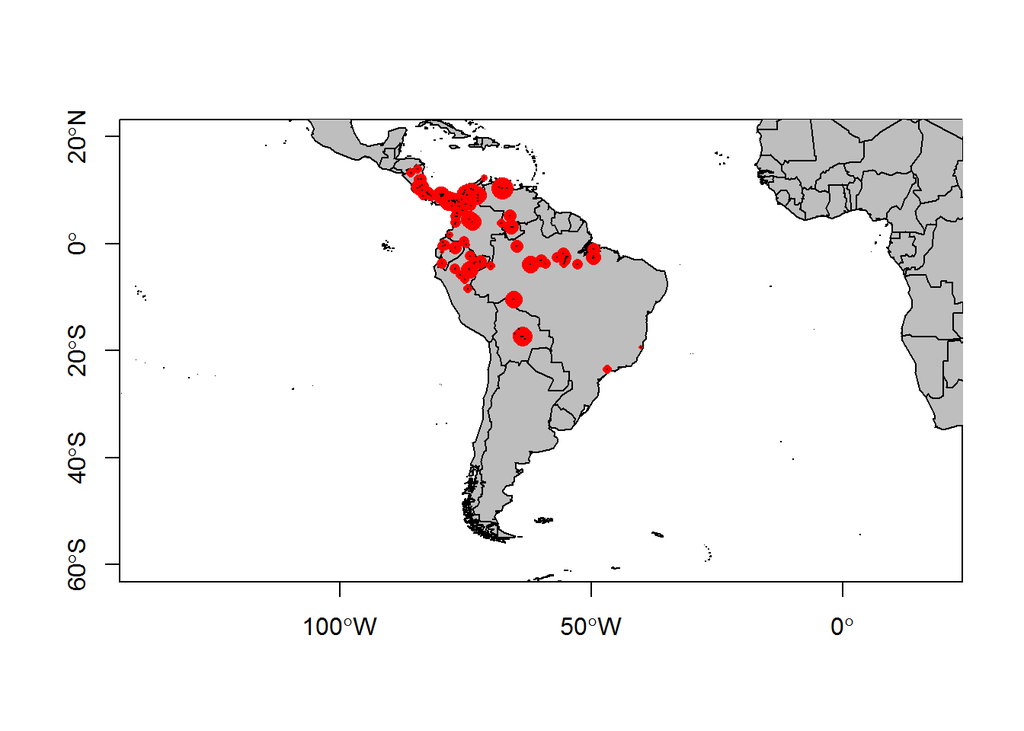

```r
plot(wrld_simpl, xlim=c(-90, -30), ylim=c(-60, 20),
axes=T, col="gray")

points(dados, pch=16, col="red", cex=abund/5)

points(dados, pch=16, cex=0.1)
```

Agora sim! :)

#### Extraindo dados de layers

Uma das coisas mais bacanas ao usar dados de informação geográfica no R é que temos uma tremenda capacidade de lidar com os dados “por trás” dos mapas, como em layers com variáveis ambientais, por exemplo. Vamos, então, nos divertir um pouco com isso.

Para facilitar, vamos usar os dados que vêm junto do pacote `dismo`, mas a mesma função pode ser usada para acessar dados no seu computador, ok? Vamos lá:

```r
files<-list.files(path=paste(system.file(package="dismo"),
"/ex", sep=""), pattern="grd", full.names=T)
```

Vamos aos detalhes:

- a função `list.files` faz uma lista dos arquivos de uma pasta que atendem um certo critério;
- o argumento `path` determinar a pasta escolhida (com seus dados, coloque o endereço da pasta no mesmo formato usado na `setwd`);
- o argumento `pattern` determina o tipo de arquivo que vamos ler (neste caso, gridfiles);
- o argumento `full.names` serve para vermos o endereço completo da pasta quando chamamos o objeto;

**EScolhendo os layers:**

Agora vamos separar algumas variáveis para trabalharmos. Podemos primeiro listar os arquivos, para saber a numeração de cada um:

```r
files
```

```
## [1] "C:/Users/Marcos/Documents/R/win-library/3.1/dismo/ex/bio1.grd"
## [2] "C:/Users/Marcos/Documents/R/win-library/3.1/dismo/ex/bio12.grd"
## [3] "C:/Users/Marcos/Documents/R/win-library/3.1/dismo/ex/bio16.grd"
## [4] "C:/Users/Marcos/Documents/R/win-library/3.1/dismo/ex/bio17.grd"
## [5] "C:/Users/Marcos/Documents/R/win-library/3.1/dismo/ex/bio5.grd"
## [6] "C:/Users/Marcos/Documents/R/win-library/3.1/dismo/ex/bio6.grd"
## [7] "C:/Users/Marcos/Documents/R/win-library/3.1/dismo/ex/bio7.grd"
## [8] "C:/Users/Marcos/Documents/R/win-library/3.1/dismo/ex/bio8.grd"
## [9] "C:/Users/Marcos/Documents/R/win-library/3.1/dismo/ex/biome.grd"
```

Depois, basta escolher com quem trabalhar:

```r
clima<-stack(files[1:2])

summary(clima)
```

```
##          bio1 bio12
## Min.      -23     0
## 1st Qu.   155   630
## Median    221  1234
## 3rd Qu.   256  1857
## Max.      289  7682
## NA's    25937 25936
```

Usamos a função `stack` para ler os layers desejados, e escolhemos duas variáveis (temperatura e precipitação). Note que os valores de temperatura estão multiplicados por 10, por issso parecem estranhos.

Podemos ver as variáveis que quisermos em um mapa:

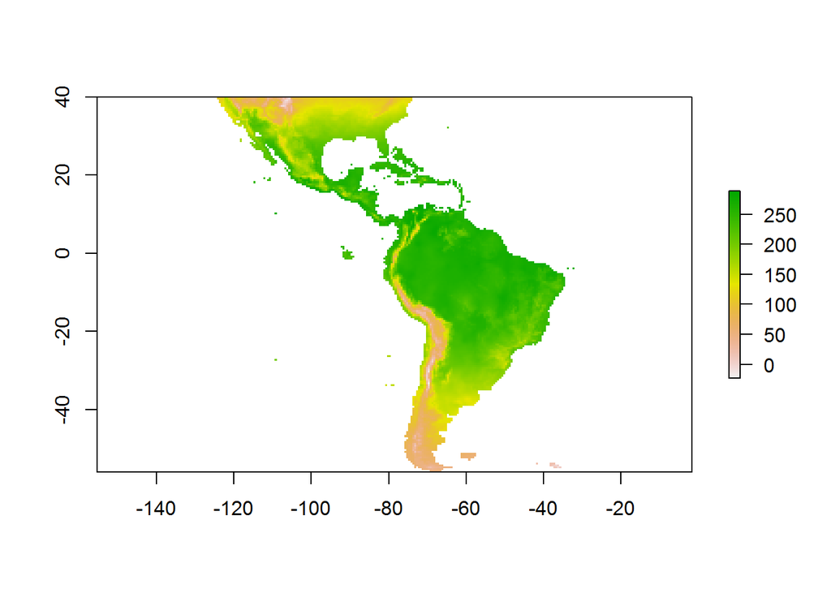

```r
plot(clima$bio1)
```

**Extraindo os valores:**

Vamos, agora, extrair os valores das duas variáveis ambientais nos nossos layers a partir dos nossos registros de coleta:

```r
clima.pontos<-extract(clima, dados)
```

Não tem mistério. Usamos a função `extract`, que é bem simples de se usar.

Vamos, então, olhar para os dados ambientais nos registros de coleta. Uma boa maneira de fazer isso é com histogramas:

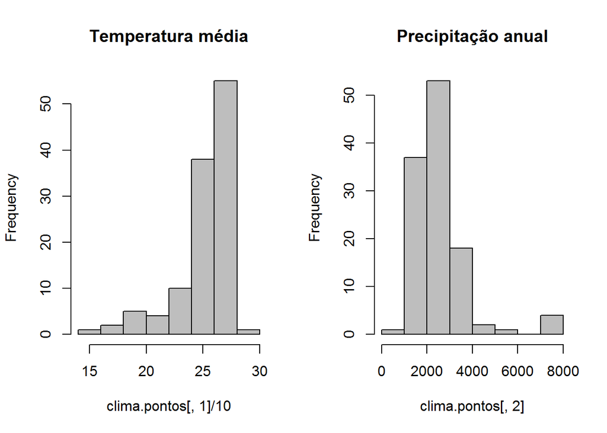

```r
par(mfrow=c(1,2))

hist(clima.pontos[,1]/10, main="Temperatura média", col="gray")
hist(clima.pontos[,2], main="Precipitação anual", col="gray")
```

Claro que também podemos olhar para os números mesmo; assim, por exemplo:

```r
quantile(clima.pontos[,1]/10, c(0, 0.1, 0.25, 0.5, 0.75,0.9, 1))
```

```
##   0%  10%  25%  50%  75%  90% 100%
## 15.0 22.1 24.4 26.0 26.6 27.1 28.2
```

```r
quantile(clima.pontos[,2]/10, c(0, 0.1, 0.25, 0.5, 0.75,0.9, 1))
```

```
##      0%     10%     25%     50%     75%     90%    100%
##  37.200 137.050 188.950 249.150 292.175 359.950 768.200
```

**Criando pontos ao acaso e comparando o clima com os registros**

Vamos criar 500 pontos ao acaso na nossa região de estudo, olharmos para eles rapidamente no mapa e depois extrairmos as mesmas variáveis ambientais para eles também:

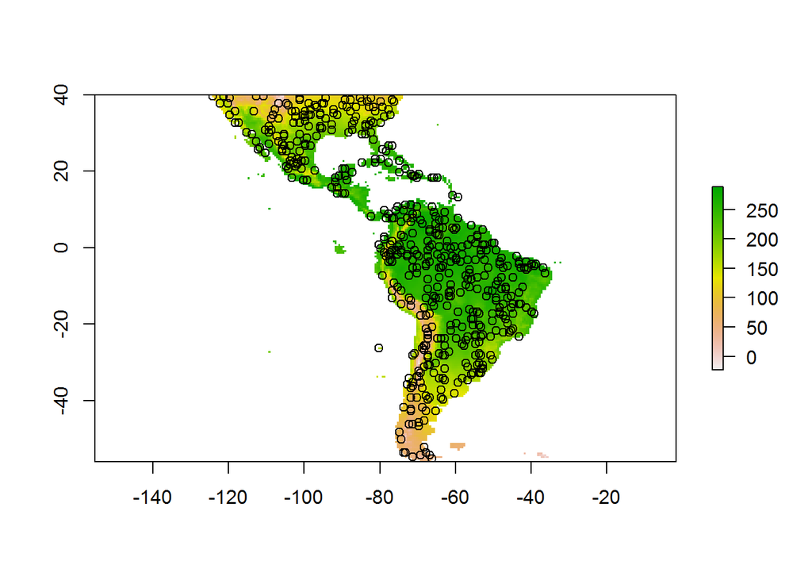

```r
pontos.acaso<-randomPoints(clima, 500)

plot(clima$bio1)
points(pontos.acaso)
```

```r
clima.acaso<-extract(clima, pontos.acaso)
```

E vamos agora comparar tudo com um boxplot:

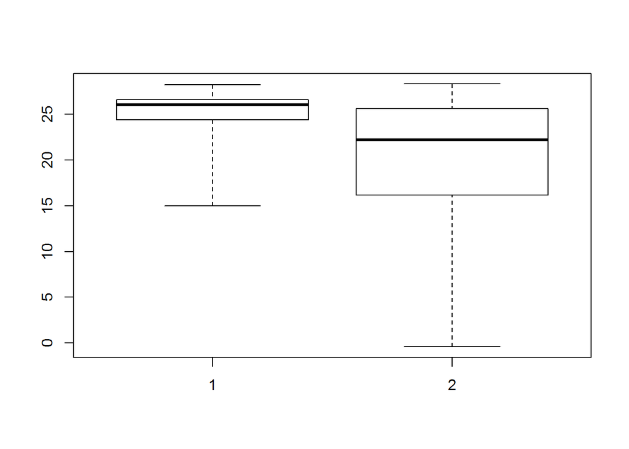

```r
boxplot(clima.pontos[,1]/10, clima.acaso[,1]/10, range=0)
```

Para terminar, imagine que você queira estudar o padrão de correlação entre duas (ou mais) variáveis ambien tais. É bem simples, você pode criar gráficos de dispersão e calcular valores de correlação. Veja o exemplo:

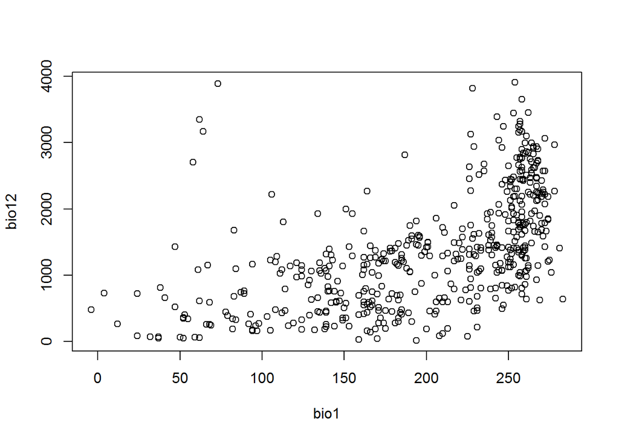

```r
plot(clima.acaso)
```

```r
#Medindo a correlação:
cor(clima.acaso, method="spearman")
```

```
##            bio1     bio12
## bio1  1.0000000 0.6421177
## bio12 0.6421177 1.0000000
```

```r
#Testando a significância da correlação:
cor.test(clima.acaso[,1],clima.acaso[,2], method="spearman")
```

```
##
##  Spearman's rank correlation rho
##
## data:  clima.acaso[, 1] and clima.acaso[, 2]
## S = 7455851, p-value < 2.2e-16
## alternative hypothesis: true rho is not equal to 0
## sample estimates:
##       rho
## 0.6421177
```

**Beleza, agora flata pouco para fecharmos tudo visto no curso!**